# Project: Wrangling and Analyze Data

1. Use the Tweepy library to query additional data via the Twitter API (tweet_json.txt)

```python
data_2  = pd.read_json("tweet_json.txt", lines=True)
tweet_json = data_2.copy()
tweet_json
```

|  | created_at | id | id_str | full_text | truncated | display_text_range | entities | extended_entities | source | in_reply_to_status_id | in_reply_to_status_id_str | in_reply_to_user_id | in_reply_to_user_id_str | in_reply_to_screen_name | user | geo | coordinates | place | contributors | is_quote_status | retweet_count | favorite_count | favorited | retweeted | possibly_sensitive | possibly_sensitive_appealable | lang | retweeted_status | quoted_status_id | … |
| --- | --- | --- | --- | --- | --- | --- | --- | --- | --- | --- | --- | --- | --- | --- | --- | --- | --- | --- | --- | --- | --- | --- | --- | --- | --- | --- | --- | --- | --- | --- |
| 0 | 2017-08-01 16:23:56+00:00 | 892420643555336193 | 892420643555336192 | This is Phineas. He's a mystical boy. Only eve... | False | [0, 85] | {'hashtags': [], 'symbols': [], 'user_mentions... | {'media': [{'id': 892420639486877696, 'id_str'... | <a href="http://twitter.com/download/iphone" r... | NaN | NaN | NaN | NaN | None | {'id': 4196983835, 'id_str': '4196983835', 'na... | NaN | NaN | None | NaN | False | 8853 | 39467 | False | False | 0.0 | 0.0 | en | NaN | NaN | … |
| 1 | 2017-08-01 00:17:27+00:00 | 892177421306343426 | 892177421306343424 | This is Tilly. She's just checking pup on you.... | False | [0, 138] | {'hashtags': [], 'symbols': [], 'user_mentions... | {'media': [{'id': 892177413194625024, 'id_str'... | <a href="http://twitter.com/download/iphone" r... | NaN | NaN | NaN | NaN | None | {'id': 4196983835, 'id_str': '4196983835', 'na... | NaN | NaN | None | NaN | False | 6514 | 33819 | False | False | 0.0 | 0.0 | en | NaN | NaN | … |
| 2 | 2017-07-31 00:18:03+00:00 | 891815181378084864 | 891815181378084864 | This is Archie. He is a rare Norwegian Pouncin... | False | [0, 121] | {'hashtags': [], 'symbols': [], 'user_mentions... | {'media': [{'id': 891815175371796480, 'id_str'... | <a href="http://twitter.com/download/iphone" r... | NaN | NaN | NaN | NaN | None | {'id': 4196983835, 'id_str': '4196983835', 'na... | NaN | NaN | None | NaN | False | 4328 | 25461 | False | False | 0.0 | 0.0 | en | NaN | NaN | … |
| 3 | 2017-07-30 15:58:51+00:00 | 891689557279858688 | 891689557279858688 | This is Darla. She commenced a snooze mid meal... | False | [0, 79] | {'hashtags': [], 'symbols': [], 'user_mentions... | {'media': [{'id': 891689552724799489, 'id_str'... | <a href="http://twitter.com/download/iphone" r... | NaN | NaN | NaN | NaN | None | {'id': 4196983835, 'id_str': '4196983835', 'na... | NaN | NaN | None | NaN | False | 8964 | 42908 | False | False | 0.0 | 0.0 | en | NaN | NaN | … |
| 4 | 2017-07-29 16:00:24+00:00 | 891327558926688256 | 891327558926688256 | This is Franklin. He would like you to stop ca... | False | [0, 138] | {'hashtags': [{'text': 'BarkWeek', 'indices': ... | {'media': [{'id': 891327551943041024, 'id_str'... | <a href="http://twitter.com/download/iphone" r... | NaN | NaN | NaN | NaN | None | {'id': 4196983835, 'id_str': '4196983835', 'na... | NaN | NaN | None | NaN | False | 9774 | 41048 | False | False | 0.0 | 0.0 | en | NaN | NaN | … |
| ... | ... | ... | ... | ... | ... | ... | ... | ... | ... | ... | ... | ... | ... | ... | ... | ... | ... | ... | ... | ... | ... | ... | ... | ... | ... | ... | ... | ... | ... | … |
| 2349 | 2015-11-16 00:24:50+00:00 | 666049248165822465 | 666049248165822464 | Here we have a 1949 1st generation vulpix. Enj... | False | [0, 120] | {'hashtags': [], 'symbols': [], 'user_mentions... | {'media': [{'id': 666049244999131136, 'id_str'... | <a href="http://twitter.com/download/iphone" r... | NaN | NaN | NaN | NaN | None | {'id': 4196983835, 'id_str': '4196983835', 'na... | NaN | NaN | None | NaN | False | 41 | 111 | False | False | 0.0 | 0.0 | en | NaN | NaN | … |
| 2350 | 2015-11-16 00:04:52+00:00 | 666044226329800704 | 666044226329800704 | This is a purebred Piers Morgan. Loves to Netf... | False | [0, 137] | {'hashtags': [], 'symbols': [], 'user_mentions... | {'media': [{'id': 666044217047650304, 'id_str'... | <a href="http://twitter.com/download/iphone" r... | NaN | NaN | NaN | NaN | None | {'id': 4196983835, 'id_str': '4196983835', 'na... | NaN | NaN | None | NaN | False | 147 | 311 | False | False | 0.0 | 0.0 | en | NaN | NaN | … |
| 2351 | 2015-11-15 23:21:54+00:00 | 666033412701032449 | 666033412701032448 | Here is a very happy pup. Big fan of well-main... | False | [0, 130] | {'hashtags': [], 'symbols': [], 'user_mentions... | {'media': [{'id': 666033409081393153, 'id_str'... | <a href="http://twitter.com/download/iphone" r... | NaN | NaN | NaN | NaN | None | {'id': 4196983835, 'id_str': '4196983835', 'na... | NaN | NaN | None | NaN | False | 47 | 128 | False | False | 0.0 | 0.0 | en | NaN | NaN | … |
| 2352 | 2015-11-15 23:05:30+00:00 | 666029285002620928 | 666029285002620928 | This is a western brown Mitsubishi terrier. Up... | False | [0, 139] | {'hashtags': [], 'symbols': [], 'user_mentions... | {'media': [{'id': 666029276303482880, 'id_str'... | <a href="http://twitter.com/download/iphone" r... | NaN | NaN | NaN | NaN | None | {'id': 4196983835, 'id_str': '4196983835', 'na... | NaN | NaN | None | NaN | False | 48 | 132 | False | False | 0.0 | 0.0 | en | NaN | NaN | … |
| 2353 | 2015-11-15 22:32:08+00:00 | 666020888022790149 | 666020888022790144 | Here we have a Japanese Irish Setter. Lost eye... | False | [0, 131] | {'hashtags': [], 'symbols': [], 'user_mentions... | {'media': [{'id': 666020881337073664, 'id_str'... | <a href="http://twitter.com/download/iphone" r... | NaN | NaN | NaN | NaN | None | {'id': 4196983835, 'id_str': '4196983835', 'na... | NaN | NaN | None | NaN | False | 532 | 2535 | False | False | 0.0 | 0.0 | en | NaN | NaN | … |

2354 rows × 31 columns

```python
tweet_json.sample(20)
```

|  | created_at | id | id_str | full_text | truncated | display_text_range | entities | extended_entities | source | in_reply_to_status_id | in_reply_to_status_id_str | in_reply_to_user_id | in_reply_to_user_id_str | in_reply_to_screen_name | user | geo | coordinates | place | contributors | is_quote_status | retweet_count | favorite_count | favorited | retweeted | possibly_sensitive | possibly_sensitive_appealable | lang | retweeted_status | quoted_status_id | … |
| --- | --- | --- | --- | --- | --- | --- | --- | --- | --- | --- | --- | --- | --- | --- | --- | --- | --- | --- | --- | --- | --- | --- | --- | --- | --- | --- | --- | --- | --- | --- |
| 2112 | 2015-11-28 02:45:17+00:00 | 670433248821026816 | 670433248821026816 | This is Sam. He's trying to escape the inordin... | False | [0, 126] | {'hashtags': [], 'symbols': [], 'user_mentions... | {'media': [{'id': 670433242026217473, 'id_str'... | <a href="http://twitter.com/download/iphone" r... | NaN | NaN | NaN | NaN | None | {'id': 4196983835, 'id_str': '4196983835', 'na... | NaN | NaN | None | NaN | False | 122 | 345 | False | False | 0.0 | 0.0 | en | NaN | NaN | … |
| 151 | 2017-05-11 17:34:13+00:00 | 862722525377298433 | 862722525377298432 | This is Dave. He passed the h*ck out. It's bar... | False | [0, 135] | {'hashtags': [], 'symbols': [], 'user_mentions... | {'media': [{'id': 862722516858445824, 'id_str'... | <a href="http://twitter.com/download/iphone" r... | NaN | NaN | NaN | NaN | None | {'id': 4196983835, 'id_str': '4196983835', 'na... | NaN | NaN | None | NaN | False | 3809 | 17779 | False | False | 0.0 | 0.0 | en | NaN | NaN | … |
| 567 | 2016-11-25 16:22:55+00:00 | 802185808107208704 | 802185808107208704 | RT @ChinoChinako: They're good products, Brent... | False | [0, 140] | {'hashtags': [], 'symbols': [], 'user_mentions... | NaN | <a href="http://twitter.com/download/iphone" r... | NaN | NaN | NaN | NaN | None | {'id': 4196983835, 'id_str': '4196983835', 'na... | NaN | NaN | None | NaN | False | 314 | 0 | False | False | NaN | NaN | en | {'created_at': 'Sat Nov 19 19:55:41 +0000 2016... | NaN | … |
| 720 | 2016-10-04 15:55:06+00:00 | 783334639985389568 | 783334639985389568 | This is Dave. He's currently in a predicament.... | False | [0, 98] | {'hashtags': [], 'symbols': [], 'user_mentions... | {'media': [{'id': 783334603142598656, 'id_str'... | <a href="http://twitter.com/download/iphone" r... | NaN | NaN | NaN | NaN | None | {'id': 4196983835, 'id_str': '4196983835', 'na... | NaN | NaN | None | NaN | False | 13616 | 32651 | False | False | 0.0 | 0.0 | en | NaN | NaN | … |
| 623 | 2016-11-07 03:14:10+00:00 | 795464331001561088 | 795464331001561088 | Elder doggo does a splash. Both 13/10 incredib... | False | [0, 54] | {'hashtags': [], 'symbols': [], 'user_mentions... | {'media': [{'id': 795464066940764160, 'id_str'... | <a href="http://twitter.com/download/iphone" r... | NaN | NaN | NaN | NaN | None | {'id': 4196983835, 'id_str': '4196983835', 'na... | NaN | NaN | None | NaN | False | 27728 | 55683 | False | False | 0.0 | 0.0 | en | NaN | NaN | … |
| 427 | 2017-01-17 00:18:04+00:00 | 821149554670182400 | 821149554670182400 | This is Luca. He got caught howling. H*ckin em... | False | [0, 62] | {'hashtags': [], 'symbols': [], 'user_mentions... | {'media': [{'id': 821149477142556673, 'id_str'... | <a href="http://twitter.com/download/iphone" r... | NaN | NaN | NaN | NaN | None | {'id': 4196983835, 'id_str': '4196983835', 'na... | NaN | NaN | None | NaN | False | 2320 | 9718 | False | False | 0.0 | 0.0 | en | NaN | NaN | … |
| 1756 | 2015-12-21 01:53:54+00:00 | 678755239630127104 | 678755239630127104 | This is Dash. He didn't think the water would ... | False | [0, 133] | {'hashtags': [], 'symbols': [], 'user_mentions... | {'media': [{'id': 678755229639151616, 'id_str'... | <a href="http://twitter.com/download/iphone" r... | NaN | NaN | NaN | NaN | None | {'id': 4196983835, 'id_str': '4196983835', 'na... | NaN | NaN | None | NaN | False | 3741 | 7802 | False | False | 0.0 | 0.0 | en | NaN | NaN | … |
| 767 | 2016-09-18 21:33:11+00:00 | 777621514455814149 | 777621514455814144 | This is Derek. You can't look at him and not s... | False | [0, 112] | {'hashtags': [], 'symbols': [], 'user_mentions... | {'media': [{'id': 777621500824260608, 'id_str'... | <a href="http://twitter.com/download/iphone" r... | NaN | NaN | NaN | NaN | None | {'id': 4196983835, 'id_str': '4196983835', 'na... | NaN | NaN | None | NaN | False | 2910 | 9742 | False | False | 0.0 | 0.0 | en | NaN | NaN | … |
| 1700 | 2015-12-27 02:15:25+00:00 | 680934982542561280 | 680934982542561280 | Say hello to Sadie. She's a Tortellini Sidewin... | False | [0, 140] | {'hashtags': [], 'symbols': [], 'user_mentions... | {'media': [{'id': 680934975001227264, 'id_str'... | <a href="http://twitter.com/download/iphone" r... | NaN | NaN | NaN | NaN | None | {'id': 4196983835, 'id_str': '4196983835', 'na... | NaN | NaN | None | NaN | False | 497 | 2285 | False | False | 0.0 | 0.0 | en | NaN | NaN | … |
| 411 | 2017-01-22 01:12:59+00:00 | 822975315408461824 | 822975315408461824 | This is Albus. He's soaked as h*ck. Seems to h... | False | [0, 118] | {'hashtags': [], 'symbols': [], 'user_mentions... | {'media': [{'id': 822975307724496896, 'id_str'... | <a href="http://twitter.com/download/iphone" r... | NaN | NaN | NaN | NaN | None | {'id': 4196983835, 'id_str': '4196983835', 'na... | NaN | NaN | None | NaN | False | 3958 | 19139 | False | False | 0.0 | 0.0 | en | NaN | NaN | … |
| 2314 | 2015-11-17 16:09:56+00:00 | 666649482315059201 | 666649482315059200 | Cool dog. Enjoys couch. Low monotone bark. Ver... | False | [0, 138] | {'hashtags': [], 'symbols': [], 'user_mentions... | {'media': [{'id': 666649475398680576, 'id_str'... | <a href="http://twitter.com/download/iphone" r... | NaN | NaN | NaN | NaN | None | {'id': 4196983835, 'id_str': '4196983835', 'na... | NaN | NaN | None | NaN | False | 608 | 923 | False | False | 0.0 | 0.0 | en | NaN | NaN | … |
| 1767 | 2015-12-20 01:03:46+00:00 | 678380236862578688 | 678380236862578688 | This is Crumpet. He underestimated the snow. Q... | False | [0, 94] | {'hashtags': [], 'symbols': [], 'user_mentions... | {'media': [{'id': 678380231556595712, 'id_str'... | <a href="http://twitter.com/download/iphone" r... | NaN | NaN | NaN | NaN | None | {'id': 4196983835, 'id_str': '4196983835', 'na... | NaN | NaN | None | NaN | False | 1020 | 2655 | False | False | 0.0 | 0.0 | en | NaN | NaN | … |
| 779 | 2016-09-13 16:30:07+00:00 | 775733305207554048 | 775733305207554048 | This is Anakin. He strives to reach his full d... | False | [0, 115] | {'hashtags': [], 'symbols': [], 'user_mentions... | {'media': [{'id': 775733297511067649, 'id_str'... | <a href="http://twitter.com/download/iphone" r... | NaN | NaN | NaN | NaN | None | {'id': 4196983835, 'id_str': '4196983835', 'na... | NaN | NaN | None | NaN | False | 4627 | 15413 | False | False | 0.0 | 0.0 | en | NaN | NaN | … |
| 1598 | 2016-01-10 02:13:27+00:00 | 686007916130873345 | 686007916130873344 | This pupper has a magical eye. 11/10 I can't s... | False | [0, 87] | {'hashtags': [], 'symbols': [], 'user_mentions... | {'media': [{'id': 686007910048989185, 'id_str'... | <a href="http://twitter.com/download/iphone" r... | NaN | NaN | NaN | NaN | None | {'id': 4196983835, 'id_str': '4196983835', 'na... | NaN | NaN | None | NaN | False | 472 | 2704 | False | False | 0.0 | 0.0 | en | NaN | NaN | … |
| 393 | 2017-01-29 22:15:05+00:00 | 825829644528148480 | 825829644528148480 | This is Toby. He just found out you only prete... | False | [0, 115] | {'hashtags': [], 'symbols': [], 'user_mentions... | {'media': [{'id': 825829613733629956, 'id_str'... | <a href="http://twitter.com/download/iphone" r... | NaN | NaN | NaN | NaN | None | {'id': 4196983835, 'id_str': '4196983835', 'na... | NaN | NaN | None | NaN | False | 2848 | 14025 | False | False | 0.0 | 0.0 | en | NaN | NaN | … |
| 142 | 2017-05-15 19:14:50+00:00 | 864197398364647424 | 864197398364647424 | This is Paisley. She ate a flower just to prov... | False | [0, 93] | {'hashtags': [], 'symbols': [], 'user_mentions... | {'media': [{'id': 864197387966791680, 'id_str'... | <a href="http://twitter.com/download/iphone" r... | NaN | NaN | NaN | NaN | None | {'id': 4196983835, 'id_str': '4196983835', 'na... | NaN | NaN | None | NaN | False | 9616 | 31459 | False | False | 0.0 | 0.0 | en | NaN | NaN | … |
| 422 | 2017-01-18 17:07:18+00:00 | 821765923262631936 | 821765923262631936 | This is Duchess. She uses dark doggo forces to... | False | [0, 82] | {'hashtags': [], 'symbols': [], 'user_mentions... | {'media': [{'id': 821765912948772865, 'id_str'... | <a href="http://twitter.com/download/iphone" r... | NaN | NaN | NaN | NaN | None | {'id': 4196983835, 'id_str': '4196983835', 'na... | NaN | NaN | None | NaN | False | 1899 | 9317 | False | False | 0.0 | 0.0 | en | NaN | NaN | … |
| 1033 | 2016-06-20 20:49:19+00:00 | 744995568523612160 | 744995568523612160 | This is Abby. She got her face stuck in a glas... | False | [0, 84] | {'hashtags': [], 'symbols': [], 'user_mentions... | {'media': [{'id': 744995559002476547, 'id_str'... | <a href="http://twitter.com/download/iphone" r... | NaN | NaN | NaN | NaN | None | {'id': 4196983835, 'id_str': '4196983835', 'na... | NaN | NaN | None | NaN | False | 716 | 3277 | False | False | 0.0 | 0.0 | en | NaN | NaN | … |
| 862 | 2016-08-08 01:44:46+00:00 | 762464539388485633 | 762464539388485632 | This is Buddy. His father was a bear and his m... | False | [0, 113] | {'hashtags': [], 'symbols': [], 'user_mentions... | {'media': [{'id': 762464530748145664, 'id_str'... | <a href="http://twitter.com/download/iphone" r... | NaN | NaN | NaN | NaN | None | {'id': 4196983835, 'id_str': '4196983835', 'na... | NaN | NaN | None | NaN | False | 4839 | 11503 | False | False | 0.0 | 0.0 | en | NaN | NaN | … |
| 903 | 2016-07-27 00:40:12+00:00 | 758099635764359168 | 758099635764359168 | In case you haven't seen the most dramatic sne... | False | [0, 87] | {'hashtags': [], 'symbols': [], 'user_mentions... | NaN | <a href="http://vine.co" rel="nofollow">Vine -... | NaN | NaN | NaN | NaN | None | {'id': 4196983835, 'id_str': '4196983835', 'na... | NaN | NaN | None | NaN | False | 11550 | 21302 | False | False | 0.0 | 0.0 | en | NaN | NaN | … |

```python
tweet_json.user[:1]
```

```
0    {'id': 4196983835, 'id_str': '4196983835', 'na...
Name: user, dtype: object
```

```python
tweet_json.info()
```

```
<class 'pandas.core.frame.DataFrame'>
RangeIndex: 2354 entries, 0 to 2353
Data columns (total 31 columns):
 #   Column                         Non-Null Count  Dtype
---  ------                         --------------  -----
 0   created_at                     2354 non-null   datetime64[ns, UTC]
 1   id                             2354 non-null   int64
 2   id_str                         2354 non-null   int64
 3   full_text                      2354 non-null   object
 4   truncated                      2354 non-null   bool
 5   display_text_range             2354 non-null   object
 6   entities                       2354 non-null   object
 7   extended_entities              2073 non-null   object
 8   source                         2354 non-null   object
 9   in_reply_to_status_id          78 non-null     float64
```

[output cut: 23 more lines]

```python
#checking if they exist a duplicate ID values in the dataset
tweet_json.id_str.nunique(), tweet_json.id.nunique()
```

```
(2354, 2354)
```

### Loading the third dataset twitter-archive-enhanced.csv

```python
data_3 = pd.read_csv("twitter-archive-enhanced.csv")
twitter_archive_enhanced = data_3.copy()
```

```python
twitter_archive_enhanced.head()
```

|  | tweet_id | in_reply_to_status_id | in_reply_to_user_id | timestamp | source | text | retweeted_status_id | retweeted_status_user_id | retweeted_status_timestamp | expanded_urls | rating_numerator | rating_denominator | name | doggo | floofer | pupper | puppo |
| --- | --- | --- | --- | --- | --- | --- | --- | --- | --- | --- | --- | --- | --- | --- | --- | --- | --- |
| 0 | 892420643555336193 | NaN | NaN | 2017-08-01 16:23:56 +0000 | <a href="http://twitter.com/download/iphone" r... | This is Phineas. He's a mystical boy. Only eve... | NaN | NaN | NaN | https://twitter.com/dog_rates/status/892420643... | 13 | 10 | Phineas | None | None | None | None |
| 1 | 892177421306343426 | NaN | NaN | 2017-08-01 00:17:27 +0000 | <a href="http://twitter.com/download/iphone" r... | This is Tilly. She's just checking pup on you.... | NaN | NaN | NaN | https://twitter.com/dog_rates/status/892177421... | 13 | 10 | Tilly | None | None | None | None |
| 2 | 891815181378084864 | NaN | NaN | 2017-07-31 00:18:03 +0000 | <a href="http://twitter.com/download/iphone" r... | This is Archie. He is a rare Norwegian Pouncin... | NaN | NaN | NaN | https://twitter.com/dog_rates/status/891815181... | 12 | 10 | Archie | None | None | None | None |
| 3 | 891689557279858688 | NaN | NaN | 2017-07-30 15:58:51 +0000 | <a href="http://twitter.com/download/iphone" r... | This is Darla. She commenced a snooze mid meal... | NaN | NaN | NaN | https://twitter.com/dog_rates/status/891689557... | 13 | 10 | Darla | None | None | None | None |
| 4 | 891327558926688256 | NaN | NaN | 2017-07-29 16:00:24 +0000 | <a href="http://twitter.com/download/iphone" r... | This is Franklin. He would like you to stop ca... | NaN | NaN | NaN | https://twitter.com/dog_rates/status/891327558... | 12 | 10 | Franklin | None | None | None | None |

```python
twitter_archive_enhanced.sample(20)
```

|  | tweet_id | in_reply_to_status_id | in_reply_to_user_id | timestamp | source | text | retweeted_status_id | retweeted_status_user_id | retweeted_status_timestamp | expanded_urls | rating_numerator | rating_denominator | name | doggo | floofer | pupper | puppo |
| --- | --- | --- | --- | --- | --- | --- | --- | --- | --- | --- | --- | --- | --- | --- | --- | --- | --- |
| 1872 | 675146535592706048 | NaN | NaN | 2015-12-11 02:54:12 +0000 | <a href="http://twitter.com/download/iphone" r... | This is Coops. He's yelling at the carpet. Not... | NaN | NaN | NaN | https://twitter.com/dog_rates/status/675146535... | 7 | 10 | Coops | None | None | None | None |
| 1370 | 702321140488925184 | NaN | NaN | 2016-02-24 02:36:23 +0000 | <a href="http://twitter.com/download/iphone" r... | Please enjoy this picture as much as I did. 12... | NaN | NaN | NaN | https://twitter.com/dog_rates/status/702321140... | 12 | 10 | None | None | None | None | None |
| 466 | 817171292965273600 | NaN | NaN | 2017-01-06 00:49:53 +0000 | <a href="http://twitter.com/download/iphone" r... | This is Tebow. He kindly requests that you put... | NaN | NaN | NaN | https://twitter.com/dog_rates/status/817171292... | 13 | 10 | Tebow | None | None | None | None |
| 674 | 789599242079838210 | NaN | NaN | 2016-10-21 22:48:24 +0000 | <a href="http://twitter.com/download/iphone" r... | This is Brownie. She's wearing a Halloween the... | NaN | NaN | NaN | https://twitter.com/dog_rates/status/789599242... | 12 | 10 | Brownie | None | None | None | None |
| 2314 | 666701168228331520 | NaN | NaN | 2015-11-17 19:35:19 +0000 | <a href="http://twitter.com/download/iphone" r... | This is a golden Buckminsterfullerene named Jo... | NaN | NaN | NaN | https://twitter.com/dog_rates/status/666701168... | 8 | 10 | a | None | None | None | None |
| 950 | 752173152931807232 | NaN | NaN | 2016-07-10 16:10:29 +0000 | <a href="http://twitter.com/download/iphone" r... | This is Brody. He's a lifeguard. Always prepar... | NaN | NaN | NaN | https://twitter.com/dog_rates/status/752173152... | 12 | 10 | Brody | None | None | None | None |
| 1862 | 675432746517426176 | NaN | NaN | 2015-12-11 21:51:30 +0000 | <a href="http://twitter.com/download/iphone" r... | Happy Friday. Here's some golden puppers. 12/1... | NaN | NaN | NaN | https://twitter.com/dog_rates/status/675432746... | 12 | 10 | None | None | None | None | None |
| 821 | 770293558247038976 | NaN | NaN | 2016-08-29 16:14:30 +0000 | <a href="http://twitter.com/download/iphone" r... | This is Jackson. There's nothing abnormal abou... | NaN | NaN | NaN | https://twitter.com/dog_rates/status/770293558... | 10 | 10 | Jackson | None | None | None | None |
| 207 | 852553447878664193 | NaN | NaN | 2017-04-13 16:05:56 +0000 | <a href="http://twitter.com/download/iphone" r... | This is Jarod. He likes having his belly brush... | NaN | NaN | NaN | https://twitter.com/dog_rates/status/852553447... | 13 | 10 | Jarod | None | None | None | None |
| 1054 | 742423170473463808 | NaN | NaN | 2016-06-13 18:27:32 +0000 | <a href="http://twitter.com/download/iphone" r... | This is Bell. She likes holding hands. 12/10 w... | NaN | NaN | NaN | https://twitter.com/dog_rates/status/742423170... | 12 | 10 | Bell | None | None | None | None |
| 1921 | 674262580978937856 | NaN | NaN | 2015-12-08 16:21:41 +0000 | <a href="http://twitter.com/download/iphone" r... | This is Gus. He's super stoked about being an ... | NaN | NaN | NaN | https://twitter.com/dog_rates/status/674262580... | 9 | 10 | Gus | None | None | pupper | None |
| 898 | 758854675097526272 | NaN | NaN | 2016-07-29 02:40:28 +0000 | <a href="http://twitter.com/download/iphone" r... | This is Lilli Bee &amp; Honey Bear. Unfortunat... | NaN | NaN | NaN | https://twitter.com/dog_rates/status/758854675... | 11 | 10 | Lilli | None | None | None | None |
| 2205 | 668633411083464705 | NaN | NaN | 2015-11-23 03:33:22 +0000 | <a href="http://twitter.com/download/iphone" r... | This is Churlie. He likes bagels. 10/10 https:... | NaN | NaN | NaN | https://twitter.com/dog_rates/status/668633411... | 10 | 10 | Churlie | None | None | None | None |
| 909 | 757725642876129280 | NaN | NaN | 2016-07-25 23:54:05 +0000 | <a href="http://twitter.com/download/iphone" r... | This is Beckham. He fell asleep at the wheel. ... | NaN | NaN | NaN | https://twitter.com/dog_rates/status/757725642... | 11 | 10 | Beckham | None | None | None | None |
| 2198 | 668815180734689280 | NaN | NaN | 2015-11-23 15:35:39 +0000 | <a href="http://twitter.com/download/iphone" r... | This is a wild Toblerone from Papua New Guinea... | NaN | NaN | NaN | https://twitter.com/dog_rates/status/668815180... | 7 | 10 | a | None | None | None | None |
| 1752 | 678969228704284672 | NaN | NaN | 2015-12-21 16:04:13 +0000 | <a href="http://twitter.com/download/iphone" r... | Meet Lola. She's a Metamorphic Chartreuse. Pla... | NaN | NaN | NaN | https://twitter.com/dog_rates/status/678969228... | 11 | 10 | Lola | None | None | None | None |
| 2285 | 667188689915760640 | NaN | NaN | 2015-11-19 03:52:34 +0000 | <a href="http://twitter.com/download/iphone" r... | Quite an advanced dog here. Impressively dress... | NaN | NaN | NaN | https://twitter.com/dog_rates/status/667188689... | 10 | 10 | None | None | None | None | None |
| 506 | 812747805718642688 | NaN | NaN | 2016-12-24 19:52:31 +0000 | <a href="http://twitter.com/download/iphone" r... | RT @dog_rates: Meet Sammy. At first I was like... | 6.800555e+17 | 4.196984e+09 | 2015-12-24 16:00:30 +0000 | https://twitter.com/dog_rates/status/680055455... | 10 | 10 | Sammy | None | None | None | None |
| 2145 | 669926384437997569 | NaN | NaN | 2015-11-26 17:11:11 +0000 | <a href="http://twitter.com/download/iphone" r... | I've never seen a dog so genuinely happy about... | NaN | NaN | NaN | https://twitter.com/dog_rates/status/669926384... | 12 | 10 | None | None | None | None | None |
| 708 | 785264754247995392 | NaN | NaN | 2016-10-09 23:44:41 +0000 | <a href="http://twitter.com/download/iphone" r... | This is Doc. He requested to be carried around... | NaN | NaN | NaN | https://twitter.com/dog_rates/status/785264754... | 12 | 10 | Doc | None | None | None | None |

```python
tweet_json.shape
```

```
(2354, 31)
```

```python
tweet_json.info()
```

```
<class 'pandas.core.frame.DataFrame'>
RangeIndex: 2354 entries, 0 to 2353
Data columns (total 31 columns):
 #   Column                         Non-Null Count  Dtype
---  ------                         --------------  -----
 0   created_at                     2354 non-null   datetime64[ns, UTC]
 1   id                             2354 non-null   int64
 2   id_str                         2354 non-null   int64
 3   full_text                      2354 non-null   object
 4   truncated                      2354 non-null   bool
 5   display_text_range             2354 non-null   object
 6   entities                       2354 non-null   object
 7   extended_entities              2073 non-null   object
 8   source                         2354 non-null   object
 9   in_reply_to_status_id          78 non-null     float64
```

[output cut: 23 more lines]

```python
tweet_json.isnull().sum()
```

```
created_at                          0
id                                  0
id_str                              0
full_text                           0
truncated                           0
display_text_range                  0
entities                            0
extended_entities                 281
source                              0
in_reply_to_status_id            2276
in_reply_to_status_id_str        2276
in_reply_to_user_id              2276
in_reply_to_user_id_str          2276
in_reply_to_screen_name          2276
user                                0
geo                              2354
coordinates                      2354
place                            2353
contributors                     2354
is_quote_status                     0
retweet_count                       0
favorite_count                      0
favorited                           0
retweeted                           0
possibly_sensitive                143
possibly_sensitive_appealable     143
lang                                0
retweeted_status                 2175
quoted_status_id                 2325
quoted_status_id_str             2325
quoted_status                    2326
dtype: int64
```

# Quality issues

### twitter_archive_enhanced

1. has null columns
2. inconsistency in values of the name column eg. a
3. remove `HTML` from the source to make it clean

### Twitter archive table

1. drop columns not needed for our analysis
2. Erroneous datatypes in these columns (tweet_id, rating_denominator,rating_numerator, in_reply_to_status_id, in_reply_to_user_id, timestamp, retweeted_status_id, retweeted_status_user_id, retweeted_status_timestamp)
3. Missing values in 'name' and dog stages represented as 'None'
- Some records have more than on dog stage
- Missing URLs in expanded_urls
- Source column is in HTML-formatted string, not a normal string
- Error in dog names (e.g a,an,actually) are not a dog's name.
- text column includes a text and a short link.

# Tidiness issues

### Image predictions Table

- Image predictions table should be added to twitter archive table

### twitter_archive_enhanced

1. The four spacies of dog(doggo, floofer, pupper, puppo) should be joined in a single column named species

### tweet_json table

1. Join `twitter_archive_enhanced`, `Image predictions` and `tweet_json` tables

# Cleaning Data

In this section, We Clean **all** of the issues documented while assessing.

```python
# Make copies of original pieces of data
image_pred_clean = image_predictions.copy()
twitter_archive_clean = twitter_archive_enhanced.copy()
tweet_json_clean = tweet_json.copy()
```

### Define

- remove duplicated values on the image prediction dataset
- remove the HTML formating on the source column in twitter_archive_clean table

# code

```python
# dropping duplicated values on the image prediction set
print("the formar lenght: ",image_predictions.shape[0])
image_predictions.drop_duplicates(subset = "jpg_url", inplace = True)
print("the new number of rows: ",image_predictions.shape[0])
```

```
the formar lenght:  2075
the new number of rows:  2009
```

```python
image_predictions.head()
```

|  | tweet_id | jpg_url | img_num | p1 | p1_conf | p1_dog | p2 | p2_conf | p2_dog | p3 | p3_conf | p3_dog |
| --- | --- | --- | --- | --- | --- | --- | --- | --- | --- | --- | --- | --- |
| 0 | 666020888022790149 | https://pbs.twimg.com/media/CT4udn0WwAA0aMy.jpg | 1 | Welsh_springer_spaniel | 0.465074 | True | collie | 0.156665 | True | Shetland_sheepdog | 0.061428 | True |
| 1 | 666029285002620928 | https://pbs.twimg.com/media/CT42GRgUYAA5iDo.jpg | 1 | redbone | 0.506826 | True | miniature_pinscher | 0.074192 | True | Rhodesian_ridgeback | 0.072010 | True |
| 2 | 666033412701032449 | https://pbs.twimg.com/media/CT4521TWwAEvMyu.jpg | 1 | German_shepherd | 0.596461 | True | malinois | 0.138584 | True | bloodhound | 0.116197 | True |
| 3 | 666044226329800704 | https://pbs.twimg.com/media/CT5Dr8HUEAA-lEu.jpg | 1 | Rhodesian_ridgeback | 0.408143 | True | redbone | 0.360687 | True | miniature_pinscher | 0.222752 | True |
| 4 | 666049248165822465 | https://pbs.twimg.com/media/CT5IQmsXIAAKY4A.jpg | 1 | miniature_pinscher | 0.560311 | True | Rottweiler | 0.243682 | True | Doberman | 0.154629 | True |

```python
twitter_archive_clean.source
```

```
0       <a href="http://twitter.com/download/iphone" r...
1       <a href="http://twitter.com/download/iphone" r...
2       <a href="http://twitter.com/download/iphone" r...
3       <a href="http://twitter.com/download/iphone" r...
4       <a href="http://twitter.com/download/iphone" r...
                              ...
2351    <a href="http://twitter.com/download/iphone" r...
2352    <a href="http://twitter.com/download/iphone" r...
2353    <a href="http://twitter.com/download/iphone" r...
2354    <a href="http://twitter.com/download/iphone" r...
2355    <a href="http://twitter.com/download/iphone" r...
Name: source, Length: 2356, dtype: object
```

```python
# remove all the  HTML formating in the source column
twitter_archive_clean['source'] = twitter_archive_clean['source'].str.replace(
    '<a href="http://twitter.com/download/iphone" rel="nofollow">Twitter for iPhone</a>', 'Twitter for iPhone')
twitter_archive_clean['source'] = twitter_archive_clean['source'].str.replace(
    '<a href="http://vine.co" rel="nofollow">Vine - Make a Scene</a>', 'Vine')
twitter_archive_clean['source'] = twitter_archive_clean['source'].str.replace(
    '<a href="http://twitter.com" rel="nofollow">Twitter Web Client</a>', 'Twitter Web Client')
twitter_archive_clean['source'] = twitter_archive_clean['source'].str.replace(
    '<a href="https://about.twitter.com/products/tweetdeck" rel="nofollow">TweetDeck</a>', 'TweetDeck')
```

### Test

```python
print("the new number of rows: ",image_predictions.shape[0])
```

```
the new number of rows:  2009
```

```python
# confirm if it has been removed
twitter_archive_clean.source.sample(5)
```

```
155     Twitter for iPhone
437     Twitter for iPhone
1080    Twitter for iPhone
764     Twitter for iPhone
1105    Twitter for iPhone
Name: source, dtype: object
```

# define

- change the Datatype of the `tweet_id`, for the tree datasets
- chnage the `timestamp` on the twitter_archive_clean to datetime

# code

```python
# Convert tweet_id to str from twitter_archive, image_prediction, twitter_data tables.
image_pred_clean.tweet_id = image_pred_clean.tweet_id.astype(str)
twitter_archive_clean.tweet_id = twitter_archive_clean.tweet_id.astype(str)
tweet_json_clean.tweet_id = tweet_json_clean.id.astype(str)
```

```python
# convert timestamp to datetime
twitter_archive_clean.timestamp = pd.to_datetime(twitter_archive_clean.timestamp)
```

# Test

```python
image_pred_clean.info()
```

```
<class 'pandas.core.frame.DataFrame'>
RangeIndex: 2075 entries, 0 to 2074
Data columns (total 12 columns):
 #   Column    Non-Null Count  Dtype
---  ------    --------------  -----
 0   tweet_id  2075 non-null   object
 1   jpg_url   2075 non-null   object
 2   img_num   2075 non-null   int64
 3   p1        2075 non-null   object
 4   p1_conf   2075 non-null   float64
 5   p1_dog    2075 non-null   bool
 6   p2        2075 non-null   object
 7   p2_conf   2075 non-null   float64
 8   p2_dog    2075 non-null   bool
 9   p3        2075 non-null   object
 10  p3_conf   2075 non-null   float64
 11  p3_dog    2075 non-null   bool
dtypes: bool(3), float64(3), int64(1), object(5)
memory usage: 152.1+ KB
```

```python
twitter_archive_clean.info()
```

```
<class 'pandas.core.frame.DataFrame'>
RangeIndex: 2356 entries, 0 to 2355
Data columns (total 17 columns):
 #   Column                      Non-Null Count  Dtype
---  ------                      --------------  -----
 0   tweet_id                    2356 non-null   object
 1   in_reply_to_status_id       78 non-null     float64
 2   in_reply_to_user_id         78 non-null     float64
 3   timestamp                   2356 non-null   datetime64[ns, UTC]
 4   source                      2356 non-null   object
 5   text                        2356 non-null   object
 6   retweeted_status_id         181 non-null    float64
 7   retweeted_status_user_id    181 non-null    float64
 8   retweeted_status_timestamp  181 non-null    object
 9   expanded_urls               2297 non-null   object
 10  rating_numerator            2356 non-null   int64
 11  rating_denominator          2356 non-null   int64
 12  name                        2356 non-null   object
 13  doggo                       2356 non-null   object
 14  floofer                     2356 non-null   object
 15  pupper                      2356 non-null   object
 16  puppo                       2356 non-null   object
dtypes: datetime64[ns, UTC](1), float64(4), int64(2), object(10)
memory usage: 313.0+ KB
```

```python
tweet_json_clean.info()
```

```
<class 'pandas.core.frame.DataFrame'>
RangeIndex: 2354 entries, 0 to 2353
Data columns (total 31 columns):
 #   Column                         Non-Null Count  Dtype
---  ------                         --------------  -----
 0   created_at                     2354 non-null   datetime64[ns, UTC]
 1   id                             2354 non-null   int64
 2   id_str                         2354 non-null   int64
 3   full_text                      2354 non-null   object
 4   truncated                      2354 non-null   bool
 5   display_text_range             2354 non-null   object
 6   entities                       2354 non-null   object
 7   extended_entities              2073 non-null   object
 8   source                         2354 non-null   object
 9   in_reply_to_status_id          78 non-null     float64
```

[output cut: 23 more lines]

# Define

#### From the twitter_archive_clean

- Drop retweeted_status_timestamp", "retweeted_status_user_id","retweeted_status_id", "in_reply_to_user_id", "in_reply_to_status_id"
- convert the four columns containing the stages of dog into one single column (doggo, floofer, pupper, puppo)
- Drop the four columns and use the newly created column (stage)
- corect the name errors and replace none with Nan

```python
twitter_archive_clean.drop(["retweeted_status_timestamp", "retweeted_status_user_id","retweeted_status_id",
                           "in_reply_to_user_id", "in_reply_to_status_id"], axis = 1, inplace = True)
```

```python
# Replacing the None values with NaN in the doggo, floofer, pupper and puppo column of the twitter_archive_clean
stages = ['doggo', 'floofer', 'pupper', 'puppo']
for stage in stages:
    twitter_archive_clean[stage] = twitter_archive_clean[stage].apply(lambda x: np.NaN if x == 'None' else x)

## Converting the four stages into one named "stages"
twitter_archive_clean['stage'] = twitter_archive_clean[['doggo', 'floofer', 'pupper', 'puppo']].astype(str).sum(1)

##replacing the 'nan', "nannannan" values for the values concatenated above with empy space
twitter_archive_clean['stage'] = twitter_archive_clean['stage'].apply(lambda x: x.replace('nan', ''))

# replacing the empty space above wit Nan
twitter_archive_clean['stage'] = twitter_archive_clean['stage'].apply(lambda x: np.NaN if x == '' else x)
```

```python
# now we need to seperate the values that was merged above
twitter_archive_clean['stage'].replace({'doggopupper':'doggo pupper',
                                'doggofloofer':'doggo floofer',
                                'doggopuppo':'doggo puppo',
                                '':None}, inplace=True)
```

```python
# image_pred_clean
twitter_archive_clean
# tweet_json_clean
```

|  | tweet_id | timestamp | source | text | expanded_urls | rating_numerator | rating_denominator | name | doggo | floofer | pupper | puppo | stage |
| --- | --- | --- | --- | --- | --- | --- | --- | --- | --- | --- | --- | --- | --- |
| 0 | 892420643555336193 | 2017-08-01 16:23:56+00:00 | Twitter for iPhone | This is Phineas. He's a mystical boy. Only eve... | https://twitter.com/dog_rates/status/892420643... | 13 | 10 | Phineas | NaN | NaN | NaN | NaN | NaN |
| 1 | 892177421306343426 | 2017-08-01 00:17:27+00:00 | Twitter for iPhone | This is Tilly. She's just checking pup on you.... | https://twitter.com/dog_rates/status/892177421... | 13 | 10 | Tilly | NaN | NaN | NaN | NaN | NaN |
| 2 | 891815181378084864 | 2017-07-31 00:18:03+00:00 | Twitter for iPhone | This is Archie. He is a rare Norwegian Pouncin... | https://twitter.com/dog_rates/status/891815181... | 12 | 10 | Archie | NaN | NaN | NaN | NaN | NaN |
| 3 | 891689557279858688 | 2017-07-30 15:58:51+00:00 | Twitter for iPhone | This is Darla. She commenced a snooze mid meal... | https://twitter.com/dog_rates/status/891689557... | 13 | 10 | Darla | NaN | NaN | NaN | NaN | NaN |
| 4 | 891327558926688256 | 2017-07-29 16:00:24+00:00 | Twitter for iPhone | This is Franklin. He would like you to stop ca... | https://twitter.com/dog_rates/status/891327558... | 12 | 10 | Franklin | NaN | NaN | NaN | NaN | NaN |
| ... | ... | ... | ... | ... | ... | ... | ... | ... | ... | ... | ... | ... | ... |
| 2351 | 666049248165822465 | 2015-11-16 00:24:50+00:00 | Twitter for iPhone | Here we have a 1949 1st generation vulpix. Enj... | https://twitter.com/dog_rates/status/666049248... | 5 | 10 | None | NaN | NaN | NaN | NaN | NaN |
| 2352 | 666044226329800704 | 2015-11-16 00:04:52+00:00 | Twitter for iPhone | This is a purebred Piers Morgan. Loves to Netf... | https://twitter.com/dog_rates/status/666044226... | 6 | 10 | a | NaN | NaN | NaN | NaN | NaN |
| 2353 | 666033412701032449 | 2015-11-15 23:21:54+00:00 | Twitter for iPhone | Here is a very happy pup. Big fan of well-main... | https://twitter.com/dog_rates/status/666033412... | 9 | 10 | a | NaN | NaN | NaN | NaN | NaN |
| 2354 | 666029285002620928 | 2015-11-15 23:05:30+00:00 | Twitter for iPhone | This is a western brown Mitsubishi terrier. Up... | https://twitter.com/dog_rates/status/666029285... | 7 | 10 | a | NaN | NaN | NaN | NaN | NaN |
| 2355 | 666020888022790149 | 2015-11-15 22:32:08+00:00 | Twitter for iPhone | Here we have a Japanese Irish Setter. Lost eye... | https://twitter.com/dog_rates/status/666020888... | 8 | 10 | None | NaN | NaN | NaN | NaN | NaN |

2356 rows × 13 columns

```python
## we now drop the four stages (doggo	floofer	pupper	puppo) since we have created a single column for that
twitter_archive_clean.drop(['doggo', 'floofer', 'pupper', 'puppo'], axis=1, inplace=True)
```

```python
# now we need to seperate the values that was merged above
twitter_archive_clean['name'].replace({'a':'NaN',
                                'None':'NaN',
                                'Nan':'NaN'}, inplace=True)
```

### Test

```python
twitter_archive_clean.head()
```

|  | tweet_id | timestamp | source | text | expanded_urls | rating_numerator | rating_denominator | name | stage |
| --- | --- | --- | --- | --- | --- | --- | --- | --- | --- |
| 0 | 892420643555336193 | 2017-08-01 16:23:56+00:00 | Twitter for iPhone | This is Phineas. He's a mystical boy. Only eve... | https://twitter.com/dog_rates/status/892420643... | 13 | 10 | Phineas | NaN |
| 1 | 892177421306343426 | 2017-08-01 00:17:27+00:00 | Twitter for iPhone | This is Tilly. She's just checking pup on you.... | https://twitter.com/dog_rates/status/892177421... | 13 | 10 | Tilly | NaN |
| 2 | 891815181378084864 | 2017-07-31 00:18:03+00:00 | Twitter for iPhone | This is Archie. He is a rare Norwegian Pouncin... | https://twitter.com/dog_rates/status/891815181... | 12 | 10 | Archie | NaN |
| 3 | 891689557279858688 | 2017-07-30 15:58:51+00:00 | Twitter for iPhone | This is Darla. She commenced a snooze mid meal... | https://twitter.com/dog_rates/status/891689557... | 13 | 10 | Darla | NaN |
| 4 | 891327558926688256 | 2017-07-29 16:00:24+00:00 | Twitter for iPhone | This is Franklin. He would like you to stop ca... | https://twitter.com/dog_rates/status/891327558... | 12 | 10 | Franklin | NaN |

```python
twitter_archive_clean.stage.value_counts()
```

```
pupper           245
doggo             83
puppo             29
doggo pupper      12
floofer            9
doggo puppo        1
doggo floofer      1
Name: stage, dtype: int64
```

```python
twitter_archive_clean.name.value_counts()
```

```
NaN           800
Charlie        12
Cooper         11
Lucy           11
Oliver         11
             ...
Aqua            1
Chase           1
Meatball        1
Rorie           1
Christoper      1
Name: name, Length: 956, dtype: int64
```

```python
twitter_archive_clean.info()
```

```
<class 'pandas.core.frame.DataFrame'>
RangeIndex: 2356 entries, 0 to 2355
Data columns (total 9 columns):
 #   Column              Non-Null Count  Dtype
---  ------              --------------  -----
 0   tweet_id            2356 non-null   object
 1   timestamp           2356 non-null   datetime64[ns, UTC]
 2   source              2356 non-null   object
 3   text                2356 non-null   object
 4   expanded_urls       2297 non-null   object
 5   rating_numerator    2356 non-null   int64
 6   rating_denominator  2356 non-null   int64
 7   name                2356 non-null   object
 8   stage               380 non-null    object
dtypes: datetime64[ns, UTC](1), int64(2), object(6)
memory usage: 165.8+ KB
```

# Define

##### Clean off the HTML formating on th `source` column

change the `ID` datatype from int to Object

##### drop the folowing on the `tweet_json_clean` table

> since some of them are almost/totally empty and some of them are not really important eg. (retweeted & favourited) since we already have the retweeted counts and the favourite counts
> - in_reply_to_status_id
> - in_reply_to_status_id_str
> - in_reply_to_user_id
> - in_reply_to_user_id_str
> - in_reply_to_screen_name
> - user
> - geo
> - coordinates
> - place
> - contributors
> - retweeted
> - favourited
> - retweeted_status
> - quoted_status_id
> - quoted_status_id_str
> - quoted_status change the `id` column name to tweet_id for easy analysis

## Code

```python
# remove all the  HTML formating in the source column
tweet_json_clean['source'] = tweet_json_clean['source'].str.replace(
    '<a href="http://twitter.com/download/iphone" rel="nofollow">Twitter for iPhone</a>', 'Twitter for iPhone')
tweet_json_clean['source'] = tweet_json_clean['source'].str.replace(
    '<a href="http://vine.co" rel="nofollow">Vine - Make a Scene</a>', 'Vine')
tweet_json_clean['source'] = tweet_json_clean['source'].str.replace(
    '<a href="http://twitter.com" rel="nofollow">Twitter Web Client</a>', 'Twitter Web Client')
tweet_json_clean['source'] = tweet_json_clean['source'].str.replace(
    '<a href="https://about.twitter.com/products/tweetdeck" rel="nofollow">TweetDeck</a>', 'TweetDeck')
```

```python
# changing the datatype of the id from integer to object
tweet_json_clean.id = tweet_json_clean.id.astype(str)
```

```python
# selecting the important features and leaving off others from the tweet_json_clean table
tweet_json_clean = tweet_json_clean[['created_at','id', 'truncated', 'display_text_range', 'source','is_quote_status', 'retweet_count', 'favorite_count','possibly_sensitive','lang']]

#changing th id column to tweet_id
cols = list(tweet_json_clean.columns)
cols[1]= "tweet_id"
tweet_json_clean.columns = cols
```

### Test

```python
tweet_json_clean.info()
```

```
<class 'pandas.core.frame.DataFrame'>
RangeIndex: 2354 entries, 0 to 2353
Data columns (total 10 columns):
 #   Column              Non-Null Count  Dtype
---  ------              --------------  -----
 0   created_at          2354 non-null   datetime64[ns, UTC]
 1   tweet_id            2354 non-null   object
 2   truncated           2354 non-null   bool
 3   display_text_range  2354 non-null   object
 4   source              2354 non-null   object
 5   is_quote_status     2354 non-null   bool
 6   retweet_count       2354 non-null   int64
 7   favorite_count      2354 non-null   int64
 8   possibly_sensitive  2211 non-null   float64
 9   lang                2354 non-null   object
dtypes: bool(2), datetime64[ns, UTC](1), float64(1), int64(2), object(4)
memory usage: 151.8+ KB
```

```python
tweet_json_clean.source
```

```
0       Twitter for iPhone
1       Twitter for iPhone
2       Twitter for iPhone
3       Twitter for iPhone
4       Twitter for iPhone
               ...
2349    Twitter for iPhone
2350    Twitter for iPhone
2351    Twitter for iPhone
2352    Twitter for iPhone
2353    Twitter for iPhone
Name: source, Length: 2354, dtype: object
```

```python
tweet_json_clean.head()
```

|  | created_at | tweet_id | truncated | display_text_range | source | is_quote_status | retweet_count | favorite_count | possibly_sensitive | lang |
| --- | --- | --- | --- | --- | --- | --- | --- | --- | --- | --- |
| 0 | 2017-08-01 16:23:56+00:00 | 892420643555336193 | False | [0, 85] | Twitter for iPhone | False | 8853 | 39467 | 0.0 | en |
| 1 | 2017-08-01 00:17:27+00:00 | 892177421306343426 | False | [0, 138] | Twitter for iPhone | False | 6514 | 33819 | 0.0 | en |
| 2 | 2017-07-31 00:18:03+00:00 | 891815181378084864 | False | [0, 121] | Twitter for iPhone | False | 4328 | 25461 | 0.0 | en |
| 3 | 2017-07-30 15:58:51+00:00 | 891689557279858688 | False | [0, 79] | Twitter for iPhone | False | 8964 | 42908 | 0.0 | en |
| 4 | 2017-07-29 16:00:24+00:00 | 891327558926688256 | False | [0, 138] | Twitter for iPhone | False | 9774 | 41048 | 0.0 | en |

#### Define:

- joining/merging the three datasets together for further analysis

#### Code

```python
 #merge the two tables
archive_clean = pd.merge(left=twitter_archive_clean, right=tweet_json_clean, how='left', on='tweet_id')

#then merging with the third table image_prediction
archive_clean = pd.merge(left=archive_clean, right=image_pred_clean, how='left', on='tweet_id')
```

#### Test

```python
archive_clean.shape
```

```
(2356, 29)
```

```python
archive_clean.info()
```

```
<class 'pandas.core.frame.DataFrame'>
Int64Index: 2356 entries, 0 to 2355
Data columns (total 29 columns):
 #   Column              Non-Null Count  Dtype
---  ------              --------------  -----
 0   tweet_id            2356 non-null   object
 1   timestamp           2356 non-null   datetime64[ns, UTC]
 2   source_x            2356 non-null   object
 3   text                2356 non-null   object
 4   expanded_urls       2297 non-null   object
 5   rating_numerator    2356 non-null   int64
 6   rating_denominator  2356 non-null   int64
 7   name                2356 non-null   object
 8   stage               380 non-null    object
 9   created_at          2354 non-null   datetime64[ns, UTC]
```

[output cut: 21 more lines]

```python
archive_clean.head()
```

|  | tweet_id | timestamp | source_x | text | expanded_urls | rating_numerator | rating_denominator | name | stage | created_at | truncated | display_text_range | source_y | is_quote_status | retweet_count | favorite_count | possibly_sensitive | lang | jpg_url | img_num | p1 | p1_conf | p1_dog | p2 | p2_conf | p2_dog | p3 | p3_conf | p3_dog |
| --- | --- | --- | --- | --- | --- | --- | --- | --- | --- | --- | --- | --- | --- | --- | --- | --- | --- | --- | --- | --- | --- | --- | --- | --- | --- | --- | --- | --- | --- |
| 0 | 892420643555336193 | 2017-08-01 16:23:56+00:00 | Twitter for iPhone | This is Phineas. He's a mystical boy. Only eve... | https://twitter.com/dog_rates/status/892420643... | 13 | 10 | Phineas | NaN | 2017-08-01 16:23:56+00:00 | False | [0, 85] | Twitter for iPhone | False | 8853.0 | 39467.0 | 0.0 | en | https://pbs.twimg.com/media/DGKD1-bXoAAIAUK.jpg | 1.0 | orange | 0.097049 | False | bagel | 0.085851 | False | banana | 0.076110 | False |
| 1 | 892177421306343426 | 2017-08-01 00:17:27+00:00 | Twitter for iPhone | This is Tilly. She's just checking pup on you.... | https://twitter.com/dog_rates/status/892177421... | 13 | 10 | Tilly | NaN | 2017-08-01 00:17:27+00:00 | False | [0, 138] | Twitter for iPhone | False | 6514.0 | 33819.0 | 0.0 | en | https://pbs.twimg.com/media/DGGmoV4XsAAUL6n.jpg | 1.0 | Chihuahua | 0.323581 | True | Pekinese | 0.090647 | True | papillon | 0.068957 | True |
| 2 | 891815181378084864 | 2017-07-31 00:18:03+00:00 | Twitter for iPhone | This is Archie. He is a rare Norwegian Pouncin... | https://twitter.com/dog_rates/status/891815181... | 12 | 10 | Archie | NaN | 2017-07-31 00:18:03+00:00 | False | [0, 121] | Twitter for iPhone | False | 4328.0 | 25461.0 | 0.0 | en | https://pbs.twimg.com/media/DGBdLU1WsAANxJ9.jpg | 1.0 | Chihuahua | 0.716012 | True | malamute | 0.078253 | True | kelpie | 0.031379 | True |
| 3 | 891689557279858688 | 2017-07-30 15:58:51+00:00 | Twitter for iPhone | This is Darla. She commenced a snooze mid meal... | https://twitter.com/dog_rates/status/891689557... | 13 | 10 | Darla | NaN | 2017-07-30 15:58:51+00:00 | False | [0, 79] | Twitter for iPhone | False | 8964.0 | 42908.0 | 0.0 | en | https://pbs.twimg.com/media/DF_q7IAWsAEuuN8.jpg | 1.0 | paper_towel | 0.170278 | False | Labrador_retriever | 0.168086 | True | spatula | 0.040836 | False |
| 4 | 891327558926688256 | 2017-07-29 16:00:24+00:00 | Twitter for iPhone | This is Franklin. He would like you to stop ca... | https://twitter.com/dog_rates/status/891327558... | 12 | 10 | Franklin | NaN | 2017-07-29 16:00:24+00:00 | False | [0, 138] | Twitter for iPhone | False | 9774.0 | 41048.0 | 0.0 | en | https://pbs.twimg.com/media/DF6hr6BUMAAzZgT.jpg | 2.0 | basset | 0.555712 | True | English_springer | 0.225770 | True | German_short-haired_pointer | 0.175219 | True |

```python
#we have source_x and source_y, so we need to drop one of the sources before storing
archive_clean.drop("source_y", axis = 1, inplace = True)

# rename the source_x column to source
archive_clean.rename(columns = {"source_x": "source"},
          inplace = True)
```

## Storing Data

Storing the gathered, assessed, and cleaned master dataset to a CSV file named "twitter_archive_master.csv".

```python
# i will be commenting the code below so we dont have to keep creating file in our disk after reruning the code

# archive_clean.to_csv('twitter_archive_master.csv', index=False)
```

## Analyzing and Visualizing Data

```python
twitter_archive_master = pd.read_csv('twitter_archive_master.csv')
```

```python
twitter_archive_master.head(2)
```

|  | tweet_id | timestamp | source | text | expanded_urls | rating_numerator | rating_denominator | name | stage | created_at | truncated | display_text_range | is_quote_status | retweet_count | favorite_count | possibly_sensitive | lang | jpg_url | img_num | p1 | p1_conf | p1_dog | p2 | p2_conf | p2_dog | p3 | p3_conf | p3_dog |
| --- | --- | --- | --- | --- | --- | --- | --- | --- | --- | --- | --- | --- | --- | --- | --- | --- | --- | --- | --- | --- | --- | --- | --- | --- | --- | --- | --- | --- |
| 0 | 892420643555336193 | 2017-08-01 16:23:56+00:00 | Twitter for iPhone | This is Phineas. He's a mystical boy. Only eve... | https://twitter.com/dog_rates/status/892420643... | 13 | 10 | Phineas | NaN | 2017-08-01 16:23:56+00:00 | False | [0, 85] | False | 8853.0 | 39467.0 | 0.0 | en | https://pbs.twimg.com/media/DGKD1-bXoAAIAUK.jpg | 1.0 | orange | 0.097049 | False | bagel | 0.085851 | False | banana | 0.076110 | False |
| 1 | 892177421306343426 | 2017-08-01 00:17:27+00:00 | Twitter for iPhone | This is Tilly. She's just checking pup on you.... | https://twitter.com/dog_rates/status/892177421... | 13 | 10 | Tilly | NaN | 2017-08-01 00:17:27+00:00 | False | [0, 138] | False | 6514.0 | 33819.0 | 0.0 | en | https://pbs.twimg.com/media/DGGmoV4XsAAUL6n.jpg | 1.0 | Chihuahua | 0.323581 | True | Pekinese | 0.090647 | True | papillon | 0.068957 | True |

```python
twitter_archive_master.info()
```

```
<class 'pandas.core.frame.DataFrame'>
RangeIndex: 2356 entries, 0 to 2355
Data columns (total 28 columns):
 #   Column              Non-Null Count  Dtype
---  ------              --------------  -----
 0   tweet_id            2356 non-null   int64
 1   timestamp           2356 non-null   object
 2   source              2356 non-null   object
 3   text                2356 non-null   object
 4   expanded_urls       2297 non-null   object
 5   rating_numerator    2356 non-null   int64
 6   rating_denominator  2356 non-null   int64
 7   name                1556 non-null   object
 8   stage               380 non-null    object
 9   created_at          2354 non-null   object
```

[output cut: 20 more lines]

**The datatypes lost its properties on saving and loading it back**

- we need to convert it back to a better/supposed state

```python
 # Change types
twitter_archive_master.tweet_id = twitter_archive_master.tweet_id.astype(str)
twitter_archive_master.timestamp = pd.to_datetime(twitter_archive_master.timestamp)
```

```python
twitter_archive_master.info()
```

```
<class 'pandas.core.frame.DataFrame'>
RangeIndex: 2356 entries, 0 to 2355
Data columns (total 28 columns):
 #   Column              Non-Null Count  Dtype
---  ------              --------------  -----
 0   tweet_id            2356 non-null   object
 1   timestamp           2356 non-null   datetime64[ns, UTC]
 2   source              2356 non-null   object
 3   text                2356 non-null   object
 4   expanded_urls       2297 non-null   object
 5   rating_numerator    2356 non-null   int64
 6   rating_denominator  2356 non-null   int64
 7   name                1556 non-null   object
 8   stage               380 non-null    object
 9   created_at          2354 non-null   object
```

[output cut: 20 more lines]

```python
twitter_archive_master.source.value_counts()
```

```
Twitter for iPhone    2221
Vine                    91
Twitter Web Client      33
TweetDeck               11
Name: source, dtype: int64
```

```python
twitter_archive_master.name.value_counts()
```

```
Charlie       12
Cooper        11
Lucy          11
Oliver        11
Tucker        10
              ..
Aqua           1
Chase          1
Meatball       1
Rorie          1
Christoper     1
Name: name, Length: 955, dtype: int64
```

```python
twitter_archive_master.stage.value_counts()
```

```
pupper           245
doggo             83
puppo             29
doggo pupper      12
floofer            9
doggo puppo        1
doggo floofer      1
Name: stage, dtype: int64
```

```python
twitter_archive_master.lang.value_counts()
```

```
en     2336
und       7
in        3
nl        3
eu        1
es        1
tl        1
ro        1
et        1
Name: lang, dtype: int64
```

# Insights:

1. from the `source` column : Twitter for iPhone has the highest population
2. pupper has the highest population on the stages of Dog
3. en(english) has the highest population in the `lang` columns

### Visualization

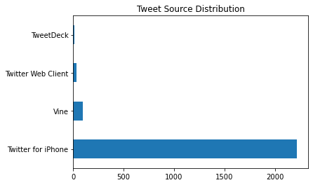

```python
twitter_archive_master.source.value_counts().plot(kind = "barh", title = "Tweet Source Distribution");
```

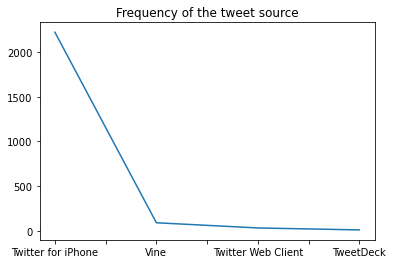

```python
twitter_archive_master.source.value_counts().plot(kind = "line",
                                                 title = ("Frequency of the tweet source"));
```

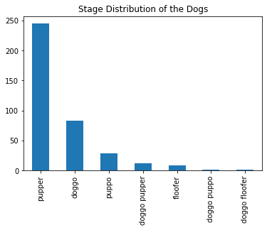

```python
twitter_archive_master.stage.value_counts().plot(kind = "bar",
                                                title = "Stage Distribution of the Dogs");
```

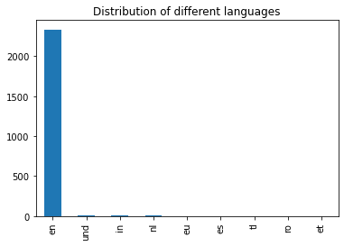

```python
twitter_archive_master.lang.value_counts().plot(kind = "bar",
                                               title = "Distribution of different languages");
```

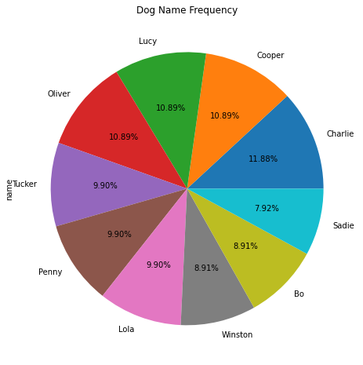

```python
plt.figure(figsize=(12, 8))
dog_names = twitter_archive_master.name.value_counts().nlargest(10).plot(kind = 'pie', autopct = '%1.2f%%');
dog_names.set_title('Dog Name Frequency');
```